# Risk Factor Analysis

## Outcome Variable

**Outcome Variable:** swasted

## Predictor Variables

**Intervention Variable:** mage

**Adjustment Set:**

- arm
- meducyrs
- feducyrs
- W_mhtcm
- single
- delta_meducyrs
- delta_feducyrs
- delta_W_mhtcm
- delta_single

## Stratifying Variables

The analysis was stratified on these variable(s):

- agecat
- studyid
- country

## Data Summary

| agecat | studyid | country | mage | swasted | n_cell | n |
| --- | --- | --- | --- | --- | --- | --- |
| Birth | ki0047075b-MAL-ED | BANGLADESH | [20-30) | 0 | 158 | 241 |
| Birth | ki0047075b-MAL-ED | BANGLADESH | [20-30) | 1 | 6 | 241 |
| Birth | ki0047075b-MAL-ED | BANGLADESH | <20 | 0 | 34 | 241 |
| Birth | ki0047075b-MAL-ED | BANGLADESH | <20 | 1 | 0 | 241 |
| Birth | ki0047075b-MAL-ED | BANGLADESH | >=30 | 0 | 41 | 241 |
| Birth | ki0047075b-MAL-ED | BANGLADESH | >=30 | 1 | 2 | 241 |
| Birth | ki0047075b-MAL-ED | BRAZIL | [20-30) | 0 | 110 | 183 |
| Birth | ki0047075b-MAL-ED | BRAZIL | [20-30) | 1 | 0 | 183 |
| Birth | ki0047075b-MAL-ED | BRAZIL | <20 | 0 | 34 | 183 |
| Birth | ki0047075b-MAL-ED | BRAZIL | <20 | 1 | 0 | 183 |
| Birth | ki0047075b-MAL-ED | BRAZIL | >=30 | 0 | 39 | 183 |
| Birth | ki0047075b-MAL-ED | BRAZIL | >=30 | 1 | 0 | 183 |
| Birth | ki0047075b-MAL-ED | INDIA | [20-30) | 0 | 158 | 202 |
| Birth | ki0047075b-MAL-ED | INDIA | [20-30) | 1 | 5 | 202 |
| Birth | ki0047075b-MAL-ED | INDIA | <20 | 0 | 22 | 202 |
| Birth | ki0047075b-MAL-ED | INDIA | <20 | 1 | 2 | 202 |
| Birth | ki0047075b-MAL-ED | INDIA | >=30 | 0 | 15 | 202 |
| Birth | ki0047075b-MAL-ED | INDIA | >=30 | 1 | 0 | 202 |
| Birth | ki0047075b-MAL-ED | NEPAL | [20-30) | 0 | 125 | 168 |
| Birth | ki0047075b-MAL-ED | NEPAL | [20-30) | 1 | 4 | 168 |
| Birth | ki0047075b-MAL-ED | NEPAL | <20 | 0 | 4 | 168 |
| Birth | ki0047075b-MAL-ED | NEPAL | <20 | 1 | 0 | 168 |
| Birth | ki0047075b-MAL-ED | NEPAL | >=30 | 0 | 35 | 168 |
| Birth | ki0047075b-MAL-ED | NEPAL | >=30 | 1 | 0 | 168 |
| Birth | ki0047075b-MAL-ED | PERU | [20-30) | 0 | 142 | 279 |
| Birth | ki0047075b-MAL-ED | PERU | [20-30) | 1 | 0 | 279 |
| Birth | ki0047075b-MAL-ED | PERU | <20 | 0 | 73 | 279 |
| Birth | ki0047075b-MAL-ED | PERU | <20 | 1 | 0 | 279 |
| Birth | ki0047075b-MAL-ED | PERU | >=30 | 0 | 64 | 279 |
| Birth | ki0047075b-MAL-ED | PERU | >=30 | 1 | 0 | 279 |

[output cut: 378 more lines]

The following strata were considered:

- agecat: 24 months, studyid: ki0047075b-MAL-ED, country: BANGLADESH
- agecat: 24 months, studyid: ki0047075b-MAL-ED, country: BRAZIL
- agecat: 24 months, studyid: ki0047075b-MAL-ED, country: INDIA
- agecat: 24 months, studyid: ki0047075b-MAL-ED, country: NEPAL
- agecat: 24 months, studyid: ki0047075b-MAL-ED, country: PERU
- agecat: 24 months, studyid: ki0047075b-MAL-ED, country: SOUTH AFRICA
- agecat: 24 months, studyid: ki0047075b-MAL-ED, country: TANZANIA, UNITED REPUBLIC OF
- agecat: 24 months, studyid: ki1000108-CMC-V-BCS-2002, country: INDIA
- agecat: 24 months, studyid: ki1000108-IRC, country: INDIA
- agecat: 24 months, studyid: ki1017093-NIH-Birth, country: BANGLADESH
- agecat: 24 months, studyid: ki1017093b-PROVIDE, country: BANGLADESH
- agecat: 24 months, studyid: ki1017093c-NIH-Crypto, country: BANGLADESH
- agecat: 24 months, studyid: ki1066203-TanzaniaChild2, country: TANZANIA, UNITED REPUBLIC OF
- agecat: 24 months, studyid: ki1101329-Keneba, country: GAMBIA
- agecat: 24 months, studyid: ki1113344-GMS-Nepal, country: NEPAL
- agecat: 24 months, studyid: ki1119695-PROBIT, country: BELARUS
- agecat: 24 months, studyid: ki1126311-ZVITAMBO, country: ZIMBABWE
- agecat: 24 months, studyid: ki1135781-COHORTS, country: GUATEMALA
- agecat: 24 months, studyid: ki1135781-COHORTS, country: INDIA
- agecat: 24 months, studyid: ki1135781-COHORTS, country: PHILIPPINES
- agecat: 24 months, studyid: ki1148112-LCNI-5, country: MALAWI
- agecat: 24 months, studyid: kiGH5241-JiVitA-3, country: BANGLADESH
- agecat: 6 months, studyid: ki0047075b-MAL-ED, country: BANGLADESH
- agecat: 6 months, studyid: ki0047075b-MAL-ED, country: BRAZIL
- agecat: 6 months, studyid: ki0047075b-MAL-ED, country: INDIA
- agecat: 6 months, studyid: ki0047075b-MAL-ED, country: NEPAL
- agecat: 6 months, studyid: ki0047075b-MAL-ED, country: PERU
- agecat: 6 months, studyid: ki0047075b-MAL-ED, country: SOUTH AFRICA
- agecat: 6 months, studyid: ki0047075b-MAL-ED, country: TANZANIA, UNITED REPUBLIC OF
- agecat: 6 months, studyid: ki1000108-CMC-V-BCS-2002, country: INDIA
- agecat: 6 months, studyid: ki1000108-IRC, country: INDIA
- agecat: 6 months, studyid: ki1000109-EE, country: PAKISTAN
- agecat: 6 months, studyid: ki1000304b-SAS-CompFeed, country: INDIA
- agecat: 6 months, studyid: ki1000304b-SAS-FoodSuppl, country: INDIA
- agecat: 6 months, studyid: ki1017093-NIH-Birth, country: BANGLADESH
- agecat: 6 months, studyid: ki1017093b-PROVIDE, country: BANGLADESH
- agecat: 6 months, studyid: ki1017093c-NIH-Crypto, country: BANGLADESH
- agecat: 6 months, studyid: ki1066203-TanzaniaChild2, country: TANZANIA, UNITED REPUBLIC OF
- agecat: 6 months, studyid: ki1101329-Keneba, country: GAMBIA
- agecat: 6 months, studyid: ki1112895-Guatemala BSC, country: GUATEMALA
- agecat: 6 months, studyid: ki1113344-GMS-Nepal, country: NEPAL
- agecat: 6 months, studyid: ki1119695-PROBIT, country: BELARUS
- agecat: 6 months, studyid: ki1126311-ZVITAMBO, country: ZIMBABWE
- agecat: 6 months, studyid: ki1135781-COHORTS, country: GUATEMALA
- agecat: 6 months, studyid: ki1135781-COHORTS, country: INDIA
- agecat: 6 months, studyid: ki1135781-COHORTS, country: PHILIPPINES
- agecat: 6 months, studyid: ki1148112-LCNI-5, country: MALAWI
- agecat: 6 months, studyid: kiGH5241-JiVitA-3, country: BANGLADESH
- agecat: Birth, studyid: ki0047075b-MAL-ED, country: BANGLADESH
- agecat: Birth, studyid: ki0047075b-MAL-ED, country: BRAZIL
- agecat: Birth, studyid: ki0047075b-MAL-ED, country: INDIA
- agecat: Birth, studyid: ki0047075b-MAL-ED, country: NEPAL
- agecat: Birth, studyid: ki0047075b-MAL-ED, country: PERU
- agecat: Birth, studyid: ki0047075b-MAL-ED, country: SOUTH AFRICA
- agecat: Birth, studyid: ki0047075b-MAL-ED, country: TANZANIA, UNITED REPUBLIC OF
- agecat: Birth, studyid: ki1000108-CMC-V-BCS-2002, country: INDIA
- agecat: Birth, studyid: ki1000108-IRC, country: INDIA
- agecat: Birth, studyid: ki1000109-EE, country: PAKISTAN
- agecat: Birth, studyid: ki1000304b-SAS-CompFeed, country: INDIA
- agecat: Birth, studyid: ki1017093-NIH-Birth, country: BANGLADESH
- agecat: Birth, studyid: ki1017093c-NIH-Crypto, country: BANGLADESH
- agecat: Birth, studyid: ki1101329-Keneba, country: GAMBIA
- agecat: Birth, studyid: ki1119695-PROBIT, country: BELARUS
- agecat: Birth, studyid: ki1126311-ZVITAMBO, country: ZIMBABWE
- agecat: Birth, studyid: ki1135781-COHORTS, country: GUATEMALA
- agecat: Birth, studyid: ki1135781-COHORTS, country: INDIA
- agecat: Birth, studyid: ki1135781-COHORTS, country: PHILIPPINES
- agecat: Birth, studyid: kiGH5241-JiVitA-3, country: BANGLADESH

### Dropped Strata

Some strata were dropped due to rare outcomes:

- agecat: Birth, studyid: ki0047075b-MAL-ED, country: BANGLADESH
- agecat: Birth, studyid: ki0047075b-MAL-ED, country: BRAZIL
- agecat: Birth, studyid: ki0047075b-MAL-ED, country: INDIA
- agecat: Birth, studyid: ki0047075b-MAL-ED, country: NEPAL
- agecat: Birth, studyid: ki0047075b-MAL-ED, country: PERU
- agecat: Birth, studyid: ki0047075b-MAL-ED, country: SOUTH AFRICA
- agecat: Birth, studyid: ki0047075b-MAL-ED, country: TANZANIA, UNITED REPUBLIC OF
- agecat: Birth, studyid: ki1000108-CMC-V-BCS-2002, country: INDIA
- agecat: Birth, studyid: ki1000108-IRC, country: INDIA
- agecat: Birth, studyid: ki1000109-EE, country: PAKISTAN
- agecat: Birth, studyid: ki1000304b-SAS-CompFeed, country: INDIA
- agecat: Birth, studyid: ki1017093-NIH-Birth, country: BANGLADESH
- agecat: Birth, studyid: ki1017093c-NIH-Crypto, country: BANGLADESH
- agecat: Birth, studyid: ki1101329-Keneba, country: GAMBIA
- agecat: 6 months, studyid: ki0047075b-MAL-ED, country: BANGLADESH
- agecat: 6 months, studyid: ki0047075b-MAL-ED, country: BRAZIL
- agecat: 6 months, studyid: ki0047075b-MAL-ED, country: INDIA
- agecat: 6 months, studyid: ki0047075b-MAL-ED, country: NEPAL
- agecat: 6 months, studyid: ki0047075b-MAL-ED, country: PERU
- agecat: 6 months, studyid: ki0047075b-MAL-ED, country: SOUTH AFRICA
- agecat: 6 months, studyid: ki0047075b-MAL-ED, country: TANZANIA, UNITED REPUBLIC OF
- agecat: 6 months, studyid: ki1000108-CMC-V-BCS-2002, country: INDIA
- agecat: 6 months, studyid: ki1000108-IRC, country: INDIA
- agecat: 6 months, studyid: ki1000109-EE, country: PAKISTAN
- agecat: 6 months, studyid: ki1000304b-SAS-CompFeed, country: INDIA
- agecat: 6 months, studyid: ki1000304b-SAS-FoodSuppl, country: INDIA
- agecat: 6 months, studyid: ki1017093-NIH-Birth, country: BANGLADESH
- agecat: 6 months, studyid: ki1017093b-PROVIDE, country: BANGLADESH
- agecat: 6 months, studyid: ki1017093c-NIH-Crypto, country: BANGLADESH
- agecat: 6 months, studyid: ki1066203-TanzaniaChild2, country: TANZANIA, UNITED REPUBLIC OF
- agecat: 6 months, studyid: ki1112895-Guatemala BSC, country: GUATEMALA
- agecat: 6 months, studyid: ki1113344-GMS-Nepal, country: NEPAL
- agecat: 6 months, studyid: ki1119695-PROBIT, country: BELARUS
- agecat: 6 months, studyid: ki1135781-COHORTS, country: GUATEMALA
- agecat: 6 months, studyid: ki1148112-LCNI-5, country: MALAWI
- agecat: 24 months, studyid: ki0047075b-MAL-ED, country: BANGLADESH
- agecat: 24 months, studyid: ki0047075b-MAL-ED, country: BRAZIL
- agecat: 24 months, studyid: ki0047075b-MAL-ED, country: INDIA
- agecat: 24 months, studyid: ki0047075b-MAL-ED, country: NEPAL
- agecat: 24 months, studyid: ki0047075b-MAL-ED, country: PERU
- agecat: 24 months, studyid: ki0047075b-MAL-ED, country: SOUTH AFRICA
- agecat: 24 months, studyid: ki0047075b-MAL-ED, country: TANZANIA, UNITED REPUBLIC OF
- agecat: 24 months, studyid: ki1000108-CMC-V-BCS-2002, country: INDIA
- agecat: 24 months, studyid: ki1000108-IRC, country: INDIA
- agecat: 24 months, studyid: ki1017093-NIH-Birth, country: BANGLADESH
- agecat: 24 months, studyid: ki1017093b-PROVIDE, country: BANGLADESH
- agecat: 24 months, studyid: ki1017093c-NIH-Crypto, country: BANGLADESH
- agecat: 24 months, studyid: ki1066203-TanzaniaChild2, country: TANZANIA, UNITED REPUBLIC OF
- agecat: 24 months, studyid: ki1101329-Keneba, country: GAMBIA
- agecat: 24 months, studyid: ki1113344-GMS-Nepal, country: NEPAL
- agecat: 24 months, studyid: ki1119695-PROBIT, country: BELARUS
- agecat: 24 months, studyid: ki1126311-ZVITAMBO, country: ZIMBABWE
- agecat: 24 months, studyid: ki1135781-COHORTS, country: GUATEMALA
- agecat: 24 months, studyid: ki1135781-COHORTS, country: INDIA
- agecat: 24 months, studyid: ki1135781-COHORTS, country: PHILIPPINES
- agecat: 24 months, studyid: ki1148112-LCNI-5, country: MALAWI

## Methods Detail

We’re interested in the causal parameters $E[Y_a]$ for all values of $a \in \mathcal{A}$. These parameters represent the mean outcome if, possibly contrary to fact, we intervened to set all units to have $A=a$. Under the randomization and positivity assumptions, these are identified by the statistical parameters $\psi_a=E_W[E_{Y|A,W}(Y|A=a,W)]$. In addition, we’re interested in the mean of $Y$, $E[Y]$ under no intervention (the observed mean). We will estimate these parameters by using SuperLearner to fit the relevant likelihood factors – $E_{Y|A,W}(Y|A=a,W)$ and $p(A=a|W)$, and then updating our likelihood fit using a joint TMLE.

For unadjusted analyses ($W=\{\}$), initial likelihoods were estimated using Lrnr_glm to estimate the simple $E(Y|A)$ and Lrnr_mean to estimate $p(A)$. For adjusted analyses, a small library containing Lrnr_glmnet, Lrnr_xgboost, and Lrnr_mean was used.

Having estimated these parameters, we will then use the delta method to estimate relative risks and attributable risks relative to a prespecified baseline level of $A$.

# Results Detail

## Results Plots

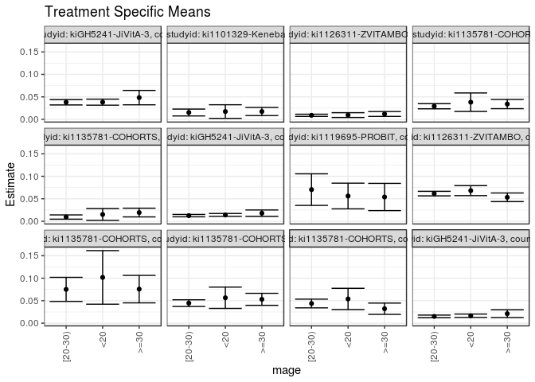

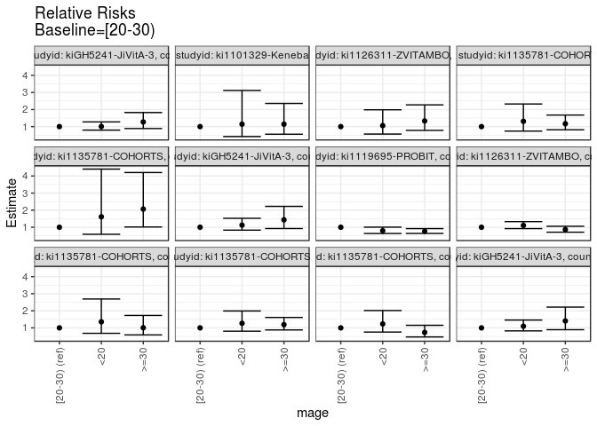

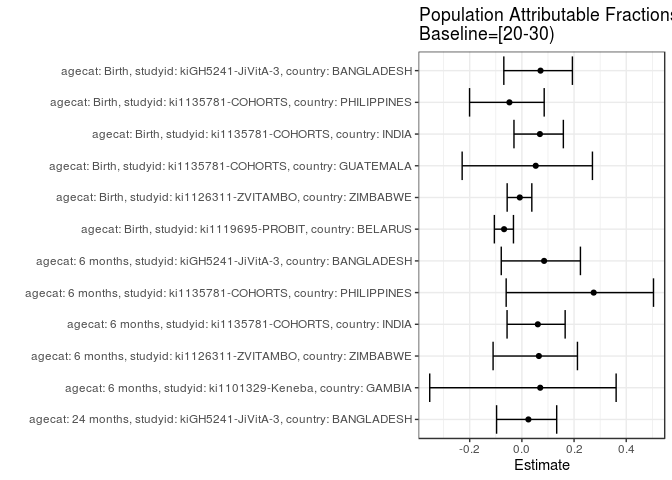

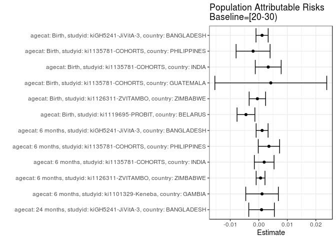

## Results Table

### Parameter: TSM

| agecat | studyid | country | intervention_level | baseline_level | estimate | ci_lower | ci_upper |
| --- | --- | --- | --- | --- | --- | --- | --- |
| Birth | ki1119695-PROBIT | BELARUS | [20-30) | NA | 0.0703967 | 0.0352477 | 0.1055457 |
| Birth | ki1119695-PROBIT | BELARUS | <20 | NA | 0.0561584 | 0.0276172 | 0.0846995 |
| Birth | ki1119695-PROBIT | BELARUS | >=30 | NA | 0.0539472 | 0.0236889 | 0.0842054 |
| Birth | ki1126311-ZVITAMBO | ZIMBABWE | [20-30) | NA | 0.0615169 | 0.0564395 | 0.0665943 |
| Birth | ki1126311-ZVITAMBO | ZIMBABWE | <20 | NA | 0.0681279 | 0.0570179 | 0.0792378 |
| Birth | ki1126311-ZVITAMBO | ZIMBABWE | >=30 | NA | 0.0533004 | 0.0437138 | 0.0628871 |
| Birth | ki1135781-COHORTS | GUATEMALA | [20-30) | NA | 0.0751495 | 0.0483405 | 0.1019584 |
| Birth | ki1135781-COHORTS | GUATEMALA | <20 | NA | 0.1017846 | 0.0421844 | 0.1613848 |
| Birth | ki1135781-COHORTS | GUATEMALA | >=30 | NA | 0.0757163 | 0.0451500 | 0.1062826 |
| Birth | ki1135781-COHORTS | INDIA | [20-30) | NA | 0.0445898 | 0.0371465 | 0.0520331 |
| Birth | ki1135781-COHORTS | INDIA | <20 | NA | 0.0564908 | 0.0328093 | 0.0801723 |
| Birth | ki1135781-COHORTS | INDIA | >=30 | NA | 0.0530292 | 0.0396693 | 0.0663890 |
| Birth | ki1135781-COHORTS | PHILIPPINES | [20-30) | NA | 0.0437332 | 0.0340454 | 0.0534210 |
| Birth | ki1135781-COHORTS | PHILIPPINES | <20 | NA | 0.0538852 | 0.0302113 | 0.0775591 |
| Birth | ki1135781-COHORTS | PHILIPPINES | >=30 | NA | 0.0321044 | 0.0195471 | 0.0446616 |
| Birth | kiGH5241-JiVitA-3 | BANGLADESH | [20-30) | NA | 0.0150199 | 0.0120525 | 0.0179874 |
| Birth | kiGH5241-JiVitA-3 | BANGLADESH | <20 | NA | 0.0164723 | 0.0127235 | 0.0202211 |
| Birth | kiGH5241-JiVitA-3 | BANGLADESH | >=30 | NA | 0.0211130 | 0.0124777 | 0.0297483 |
| 6 months | ki1101329-Keneba | GAMBIA | [20-30) | NA | 0.0151976 | 0.0075635 | 0.0228316 |
| 6 months | ki1101329-Keneba | GAMBIA | <20 | NA | 0.0173611 | 0.0022728 | 0.0324495 |
| 6 months | ki1101329-Keneba | GAMBIA | >=30 | NA | 0.0173913 | 0.0083587 | 0.0264239 |
| 6 months | ki1126311-ZVITAMBO | ZIMBABWE | [20-30) | NA | 0.0089526 | 0.0064527 | 0.0114526 |
| 6 months | ki1126311-ZVITAMBO | ZIMBABWE | <20 | NA | 0.0094680 | 0.0041246 | 0.0148115 |
| 6 months | ki1126311-ZVITAMBO | ZIMBABWE | >=30 | NA | 0.0119186 | 0.0064866 | 0.0173507 |
| 6 months | ki1135781-COHORTS | INDIA | [20-30) | NA | 0.0291431 | 0.0234117 | 0.0348745 |
| 6 months | ki1135781-COHORTS | INDIA | <20 | NA | 0.0381888 | 0.0176417 | 0.0587359 |
| 6 months | ki1135781-COHORTS | INDIA | >=30 | NA | 0.0340644 | 0.0237402 | 0.0443887 |
| 6 months | ki1135781-COHORTS | PHILIPPINES | [20-30) | NA | 0.0093750 | 0.0046521 | 0.0140979 |
| 6 months | ki1135781-COHORTS | PHILIPPINES | <20 | NA | 0.0151057 | 0.0019632 | 0.0282483 |
| 6 months | ki1135781-COHORTS | PHILIPPINES | >=30 | NA | 0.0193548 | 0.0096536 | 0.0290561 |
| 6 months | kiGH5241-JiVitA-3 | BANGLADESH | [20-30) | NA | 0.0125400 | 0.0098569 | 0.0152231 |
| 6 months | kiGH5241-JiVitA-3 | BANGLADESH | <20 | NA | 0.0141026 | 0.0109144 | 0.0172908 |
| 6 months | kiGH5241-JiVitA-3 | BANGLADESH | >=30 | NA | 0.0179778 | 0.0108799 | 0.0250758 |
| 24 months | kiGH5241-JiVitA-3 | BANGLADESH | [20-30) | NA | 0.0379884 | 0.0320235 | 0.0439533 |
| 24 months | kiGH5241-JiVitA-3 | BANGLADESH | <20 | NA | 0.0382669 | 0.0315427 | 0.0449910 |
| 24 months | kiGH5241-JiVitA-3 | BANGLADESH | >=30 | NA | 0.0483434 | 0.0323545 | 0.0643323 |

### Parameter: E(Y)

| agecat | studyid | country | intervention_level | baseline_level | estimate | ci_lower | ci_upper |
| --- | --- | --- | --- | --- | --- | --- | --- |
| Birth | ki1119695-PROBIT | BELARUS | NA | NA | 0.0658999 | 0.0328405 | 0.0989593 |
| Birth | ki1126311-ZVITAMBO | ZIMBABWE | NA | NA | 0.0610248 | 0.0568907 | 0.0651590 |
| Birth | ki1135781-COHORTS | GUATEMALA | NA | NA | 0.0793651 | 0.0600839 | 0.0986462 |
| Birth | ki1135781-COHORTS | INDIA | NA | NA | 0.0479001 | 0.0415930 | 0.0542073 |
| Birth | ki1135781-COHORTS | PHILIPPINES | NA | NA | 0.0417385 | 0.0344572 | 0.0490198 |
| Birth | kiGH5241-JiVitA-3 | BANGLADESH | NA | NA | 0.0161763 | 0.0138129 | 0.0185396 |
| 6 months | ki1101329-Keneba | GAMBIA | NA | NA | 0.0163462 | 0.0108955 | 0.0217968 |
| 6 months | ki1126311-ZVITAMBO | ZIMBABWE | NA | NA | 0.0095769 | 0.0074751 | 0.0116787 |
| 6 months | ki1135781-COHORTS | INDIA | NA | NA | 0.0310394 | 0.0261816 | 0.0358972 |
| 6 months | ki1135781-COHORTS | PHILIPPINES | NA | NA | 0.0129342 | 0.0086762 | 0.0171922 |
| 6 months | kiGH5241-JiVitA-3 | BANGLADESH | NA | NA | 0.0137076 | 0.0116310 | 0.0157842 |
| 24 months | kiGH5241-JiVitA-3 | BANGLADESH | NA | NA | 0.0389625 | 0.0346386 | 0.0432864 |

### Parameter: RR

| agecat | studyid | country | intervention_level | baseline_level | estimate | ci_lower | ci_upper |
| --- | --- | --- | --- | --- | --- | --- | --- |
| Birth | ki1119695-PROBIT | BELARUS | [20-30) | [20-30) | 1.0000000 | 1.0000000 | 1.0000000 |
| Birth | ki1119695-PROBIT | BELARUS | <20 | [20-30) | 0.7977413 | 0.6330033 | 1.0053522 |
| Birth | ki1119695-PROBIT | BELARUS | >=30 | [20-30) | 0.7663306 | 0.6371516 | 0.9216999 |
| Birth | ki1126311-ZVITAMBO | ZIMBABWE | [20-30) | [20-30) | 1.0000000 | 1.0000000 | 1.0000000 |
| Birth | ki1126311-ZVITAMBO | ZIMBABWE | <20 | [20-30) | 1.1074667 | 0.9224994 | 1.3295211 |
| Birth | ki1126311-ZVITAMBO | ZIMBABWE | >=30 | [20-30) | 0.8664362 | 0.7108751 | 1.0560388 |
| Birth | ki1135781-COHORTS | GUATEMALA | [20-30) | [20-30) | 1.0000000 | 1.0000000 | 1.0000000 |
| Birth | ki1135781-COHORTS | GUATEMALA | <20 | [20-30) | 1.3544290 | 0.6821738 | 2.6891650 |
| Birth | ki1135781-COHORTS | GUATEMALA | >=30 | [20-30) | 1.0075429 | 0.5876096 | 1.7275803 |
| Birth | ki1135781-COHORTS | INDIA | [20-30) | [20-30) | 1.0000000 | 1.0000000 | 1.0000000 |
| Birth | ki1135781-COHORTS | INDIA | <20 | [20-30) | 1.2668994 | 0.8068807 | 1.9891839 |
| Birth | ki1135781-COHORTS | INDIA | >=30 | [20-30) | 1.1892671 | 0.8791052 | 1.6088589 |
| Birth | ki1135781-COHORTS | PHILIPPINES | [20-30) | [20-30) | 1.0000000 | 1.0000000 | 1.0000000 |
| Birth | ki1135781-COHORTS | PHILIPPINES | <20 | [20-30) | 1.2321353 | 0.7532873 | 2.0153765 |
| Birth | ki1135781-COHORTS | PHILIPPINES | >=30 | [20-30) | 0.7340958 | 0.4682938 | 1.1507660 |
| Birth | kiGH5241-JiVitA-3 | BANGLADESH | [20-30) | [20-30) | 1.0000000 | 1.0000000 | 1.0000000 |
| Birth | kiGH5241-JiVitA-3 | BANGLADESH | <20 | [20-30) | 1.0966951 | 0.8246675 | 1.4584547 |
| Birth | kiGH5241-JiVitA-3 | BANGLADESH | >=30 | [20-30) | 1.4056648 | 0.8919020 | 2.2153709 |
| 6 months | ki1101329-Keneba | GAMBIA | [20-30) | [20-30) | 1.0000000 | 1.0000000 | 1.0000000 |
| 6 months | ki1101329-Keneba | GAMBIA | <20 | [20-30) | 1.1423611 | 0.4186513 | 3.1171262 |
| 6 months | ki1101329-Keneba | GAMBIA | >=30 | [20-30) | 1.1443478 | 0.5555970 | 2.3569817 |
| 6 months | ki1126311-ZVITAMBO | ZIMBABWE | [20-30) | [20-30) | 1.0000000 | 1.0000000 | 1.0000000 |
| 6 months | ki1126311-ZVITAMBO | ZIMBABWE | <20 | [20-30) | 1.0575729 | 0.5634225 | 1.9851184 |
| 6 months | ki1126311-ZVITAMBO | ZIMBABWE | >=30 | [20-30) | 1.3313033 | 0.7800081 | 2.2722437 |
| 6 months | ki1135781-COHORTS | INDIA | [20-30) | [20-30) | 1.0000000 | 1.0000000 | 1.0000000 |
| 6 months | ki1135781-COHORTS | INDIA | <20 | [20-30) | 1.3103890 | 0.7388781 | 2.3239551 |
| 6 months | ki1135781-COHORTS | INDIA | >=30 | [20-30) | 1.1688679 | 0.8144464 | 1.6775225 |
| 6 months | ki1135781-COHORTS | PHILIPPINES | [20-30) | [20-30) | 1.0000000 | 1.0000000 | 1.0000000 |
| 6 months | ki1135781-COHORTS | PHILIPPINES | <20 | [20-30) | 1.6112790 | 0.5895856 | 4.4034656 |
| 6 months | ki1135781-COHORTS | PHILIPPINES | >=30 | [20-30) | 2.0645161 | 1.0143478 | 4.2019384 |
| 6 months | kiGH5241-JiVitA-3 | BANGLADESH | [20-30) | [20-30) | 1.0000000 | 1.0000000 | 1.0000000 |
| 6 months | kiGH5241-JiVitA-3 | BANGLADESH | <20 | [20-30) | 1.1246072 | 0.8302482 | 1.5233292 |
| 6 months | kiGH5241-JiVitA-3 | BANGLADESH | >=30 | [20-30) | 1.4336364 | 0.9251170 | 2.2216794 |
| 24 months | kiGH5241-JiVitA-3 | BANGLADESH | [20-30) | [20-30) | 1.0000000 | 1.0000000 | 1.0000000 |
| 24 months | kiGH5241-JiVitA-3 | BANGLADESH | <20 | [20-30) | 1.0073313 | 0.7962018 | 1.2744462 |
| 24 months | kiGH5241-JiVitA-3 | BANGLADESH | >=30 | [20-30) | 1.2725838 | 0.8875093 | 1.8247353 |

### Parameter: PAR

| agecat | studyid | country | intervention_level | baseline_level | estimate | ci_lower | ci_upper |
| --- | --- | --- | --- | --- | --- | --- | --- |
| Birth | ki1119695-PROBIT | BELARUS | [20-30) | NA | -0.0044968 | -0.0076245 | -0.0013692 |
| Birth | ki1126311-ZVITAMBO | ZIMBABWE | [20-30) | NA | -0.0004920 | -0.0033745 | 0.0023904 |
| Birth | ki1135781-COHORTS | GUATEMALA | [20-30) | NA | 0.0042156 | -0.0154021 | 0.0238333 |
| Birth | ki1135781-COHORTS | INDIA | [20-30) | NA | 0.0033103 | -0.0012320 | 0.0078526 |
| Birth | ki1135781-COHORTS | PHILIPPINES | [20-30) | NA | -0.0019947 | -0.0079564 | 0.0039671 |
| Birth | kiGH5241-JiVitA-3 | BANGLADESH | [20-30) | NA | 0.0011564 | -0.0009786 | 0.0032914 |
| 6 months | ki1101329-Keneba | GAMBIA | [20-30) | NA | 0.0011486 | -0.0045680 | 0.0068652 |
| 6 months | ki1126311-ZVITAMBO | ZIMBABWE | [20-30) | NA | 0.0006243 | -0.0009222 | 0.0021708 |
| 6 months | ki1135781-COHORTS | INDIA | [20-30) | NA | 0.0018963 | -0.0015622 | 0.0053549 |
| 6 months | ki1135781-COHORTS | PHILIPPINES | [20-30) | NA | 0.0035592 | -0.0001903 | 0.0073087 |
| 6 months | kiGH5241-JiVitA-3 | BANGLADESH | [20-30) | NA | 0.0011676 | -0.0009258 | 0.0032609 |
| 24 months | kiGH5241-JiVitA-3 | BANGLADESH | [20-30) | NA | 0.0009742 | -0.0035113 | 0.0054597 |

### Parameter: PAF

| agecat | studyid | country | intervention_level | baseline_level | estimate | ci_lower | ci_upper |
| --- | --- | --- | --- | --- | --- | --- | --- |
| Birth | ki1119695-PROBIT | BELARUS | [20-30) | NA | -0.0682373 | -0.1054573 | -0.0322706 |
| Birth | ki1126311-ZVITAMBO | ZIMBABWE | [20-30) | NA | -0.0080626 | -0.0564147 | 0.0380764 |
| Birth | ki1135781-COHORTS | GUATEMALA | [20-30) | NA | 0.0531169 | -0.2289280 | 0.2704311 |
| Birth | ki1135781-COHORTS | INDIA | [20-30) | NA | 0.0691088 | -0.0303201 | 0.1589426 |
| Birth | ki1135781-COHORTS | PHILIPPINES | [20-30) | NA | -0.0477896 | -0.2005150 | 0.0855065 |
| Birth | kiGH5241-JiVitA-3 | BANGLADESH | [20-30) | NA | 0.0714845 | -0.0692167 | 0.1936704 |
| 6 months | ki1101329-Keneba | GAMBIA | [20-30) | NA | 0.0702664 | -0.3532073 | 0.3612179 |
| 6 months | ki1126311-ZVITAMBO | ZIMBABWE | [20-30) | NA | 0.0651891 | -0.1103663 | 0.2129882 |
| 6 months | ki1135781-COHORTS | INDIA | [20-30) | NA | 0.0610938 | -0.0568045 | 0.1658392 |
| 6 months | ki1135781-COHORTS | PHILIPPINES | [20-30) | NA | 0.2751786 | -0.0602189 | 0.5044739 |
| 6 months | kiGH5241-JiVitA-3 | BANGLADESH | [20-30) | NA | 0.0851780 | -0.0790355 | 0.2244006 |
| 24 months | kiGH5241-JiVitA-3 | BANGLADESH | [20-30) | NA | 0.0250033 | -0.0969682 | 0.1334128 |